# DDS Case Study 2 RMarkdown

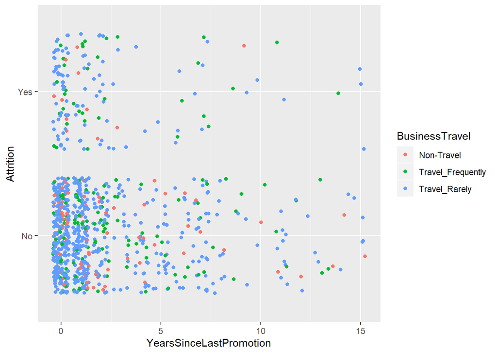

```r
ggplot(work, aes(x=YearsSinceLastPromotion, y=Attrition,color=BusinessTravel))+geom_point(position="jitter")
```

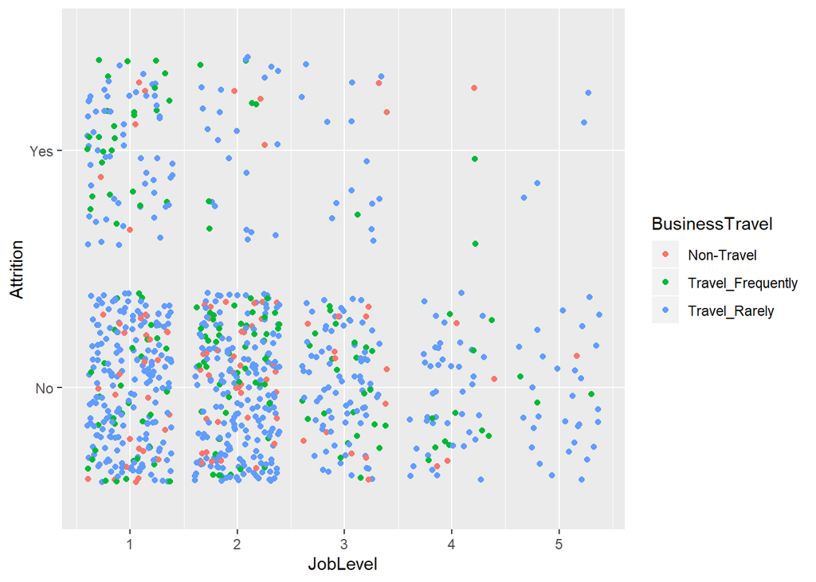

```r
ggplot(work, aes(x=JobLevel, y=Attrition,color=BusinessTravel))+geom_point(position="jitter")
```

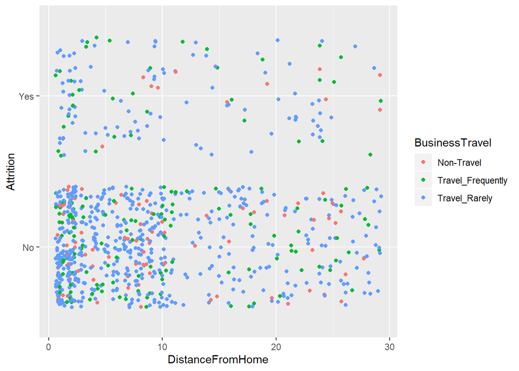

```r
ggplot(work, aes(x=DistanceFromHome, y=Attrition,color=BusinessTravel))+geom_point(position="jitter")
```

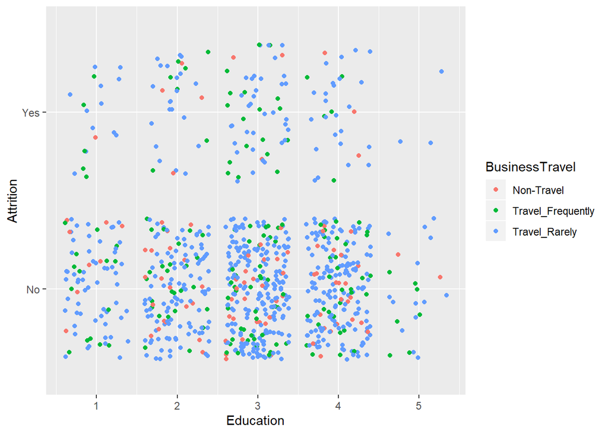

```r
ggplot(work, aes(x=Education, y=Attrition,color=BusinessTravel))+geom_point(position="jitter")
```

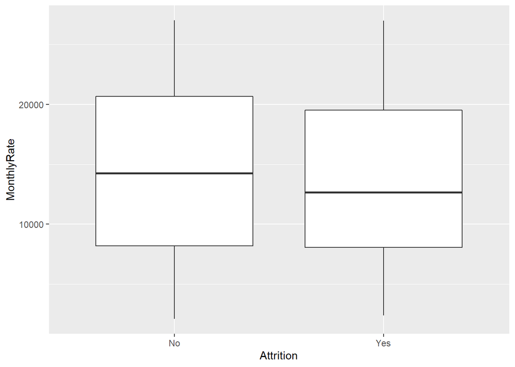

```r
#Boxplots of data
ggplot(work, aes(x=Attrition, y=MonthlyRate))+geom_boxplot()
```

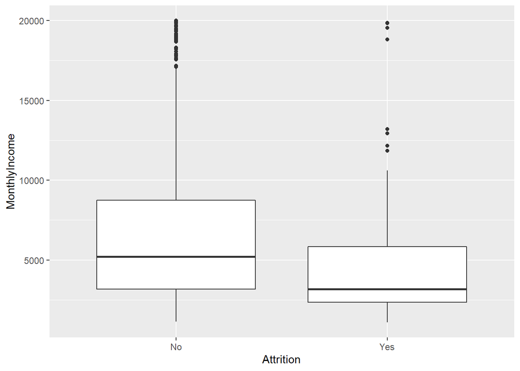

```r
ggplot(work, aes(x=Attrition, y=MonthlyIncome))+geom_boxplot()
```

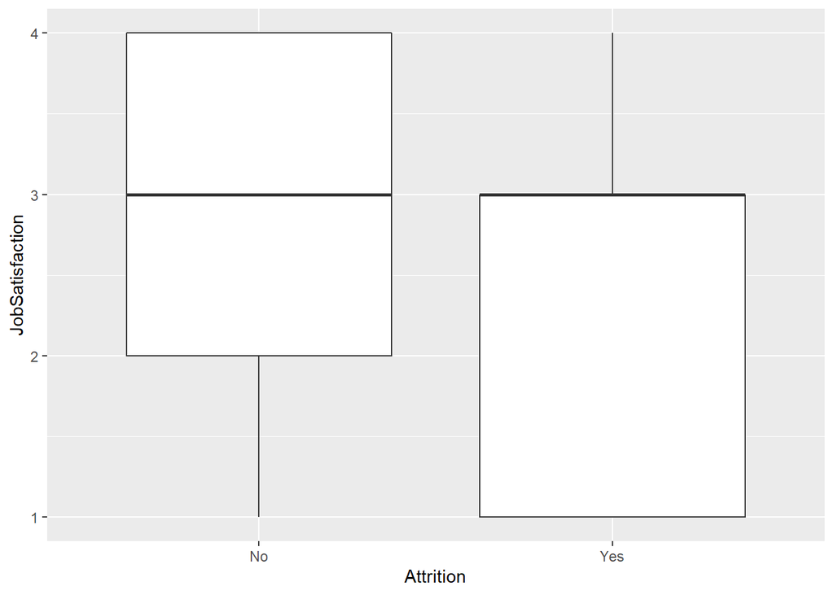

```r
ggplot(work, aes(x=Attrition, y=JobSatisfaction))+geom_boxplot()
```

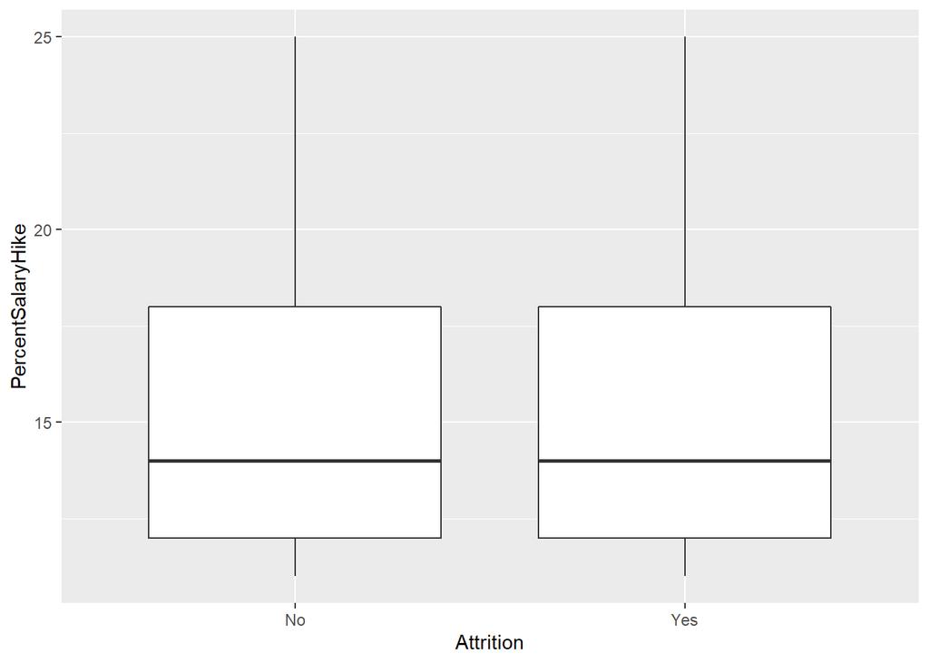

```r
ggplot(work, aes(x=Attrition, y=PercentSalaryHike))+geom_boxplot()
```

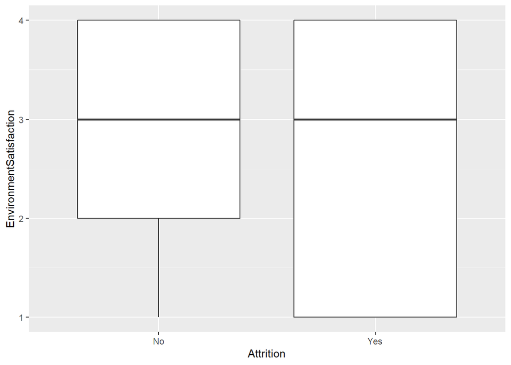

```r
ggplot(work, aes(x=Attrition, y=EnvironmentSatisfaction))+geom_boxplot()
```

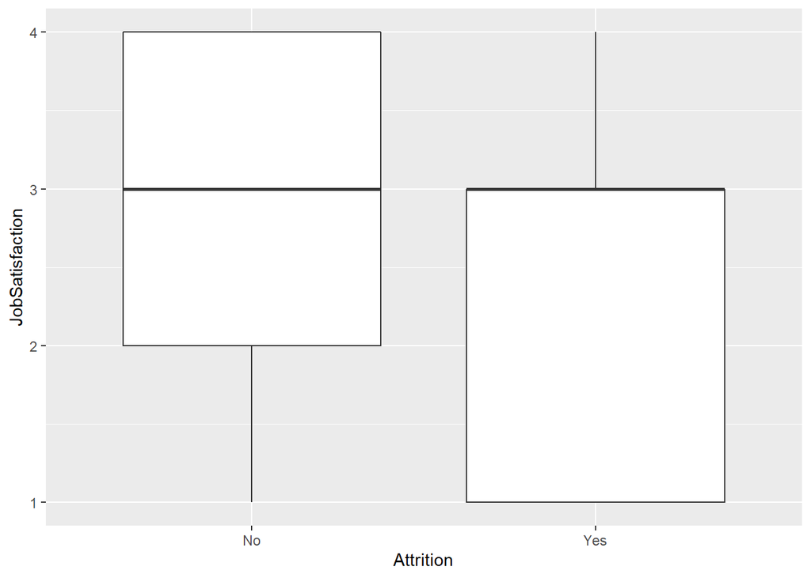

```r
ggplot(work, aes(x=Attrition, y=JobSatisfaction))+geom_boxplot()
```

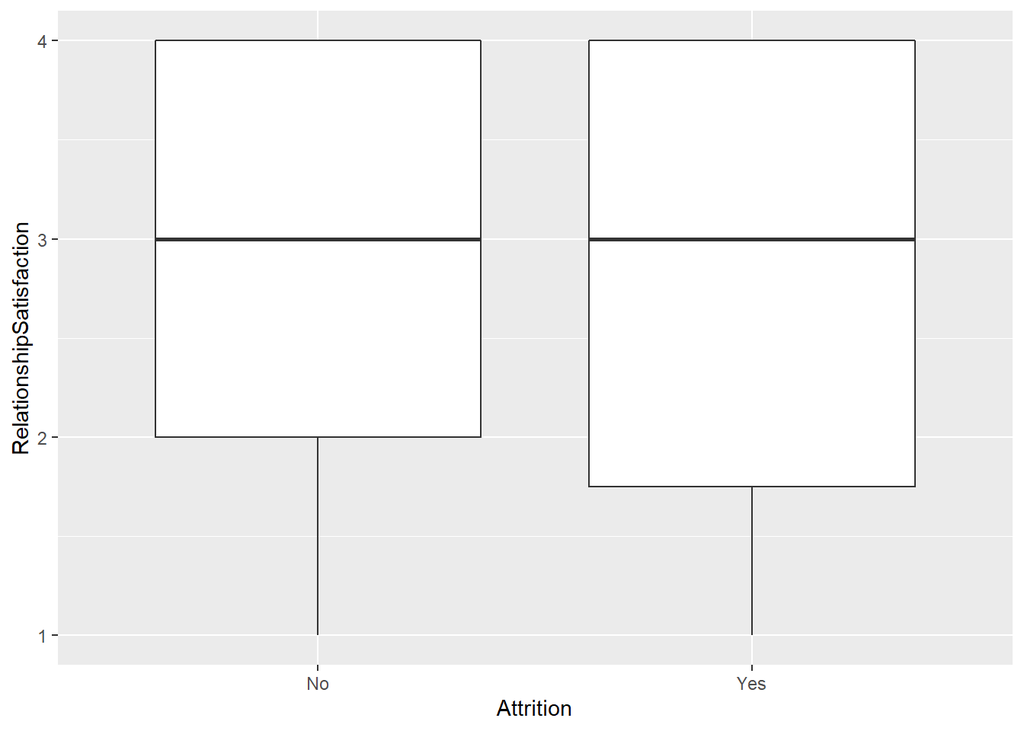

```r
ggplot(work, aes(x=Attrition, y=RelationshipSatisfaction))+geom_boxplot()
```

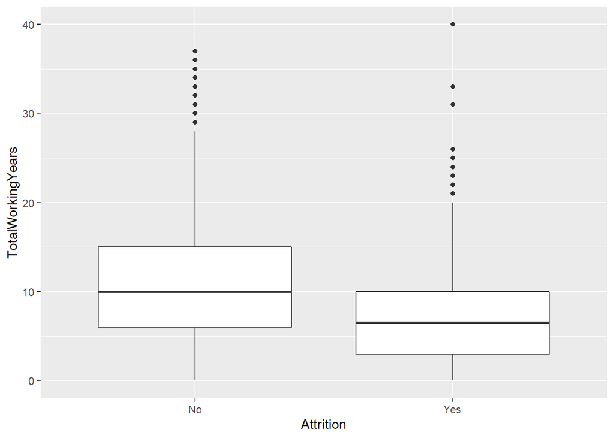

```r
ggplot(work, aes(x=Attrition, y=TotalWorkingYears))+geom_boxplot()
```

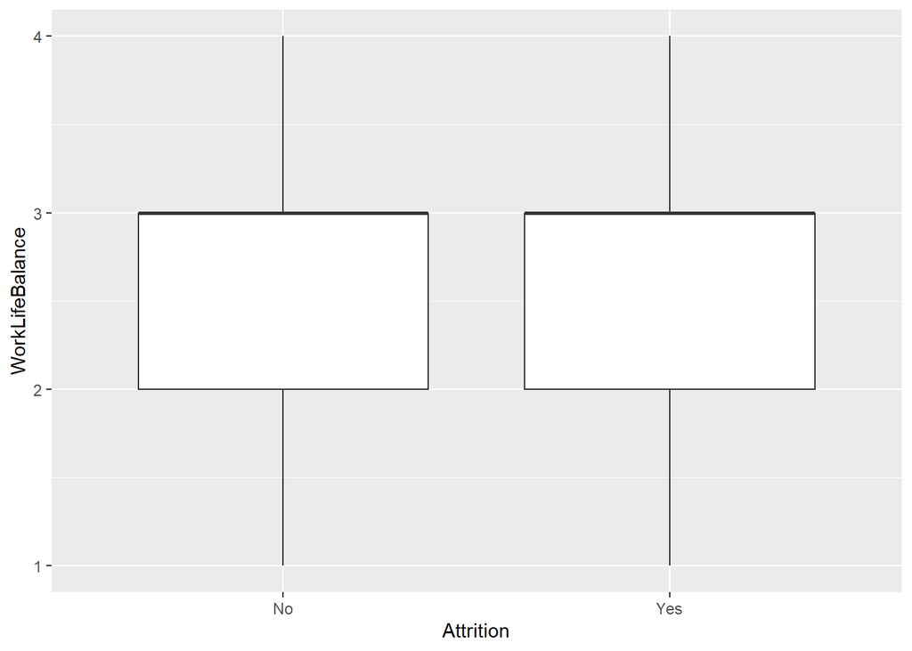

```r
ggplot(work, aes(x=Attrition, y=WorkLifeBalance))+geom_boxplot()
```

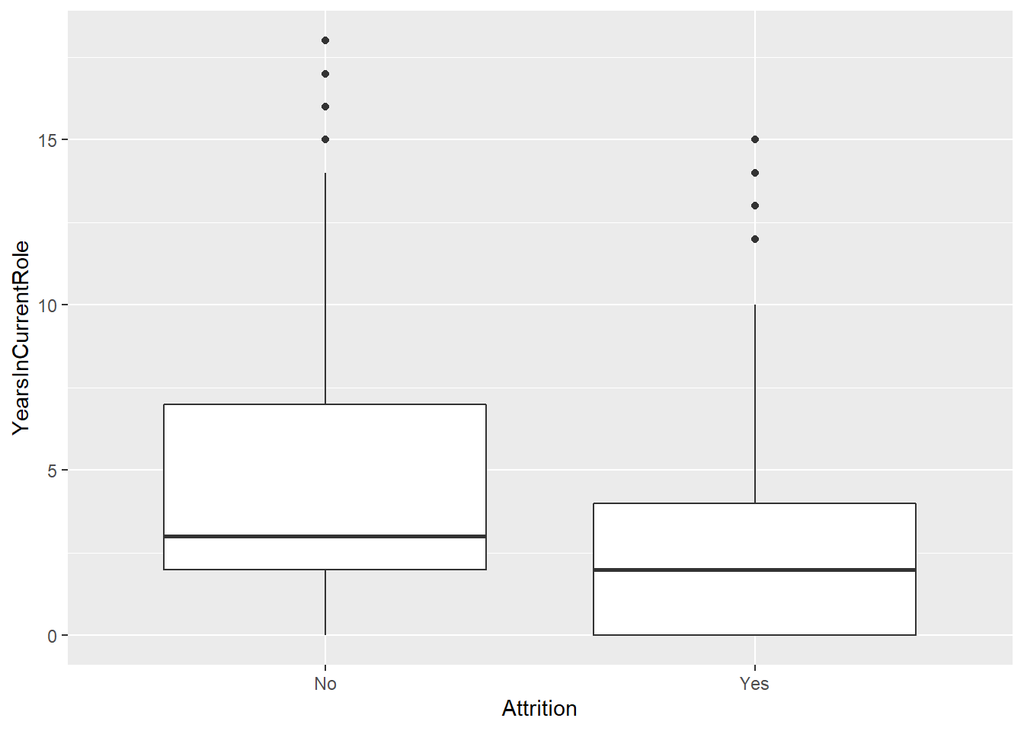

```r
ggplot(work, aes(x=Attrition, y=YearsInCurrentRole))+geom_boxplot()
```

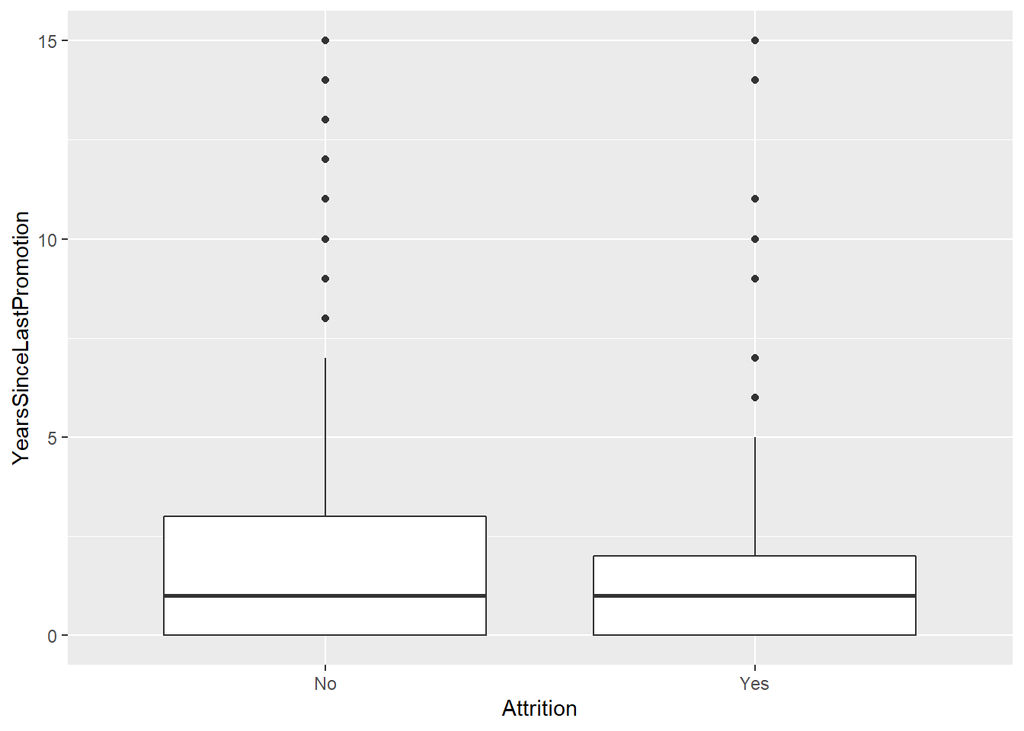

```r
ggplot(work, aes(x=Attrition, y=YearsSinceLastPromotion))+geom_boxplot()
```

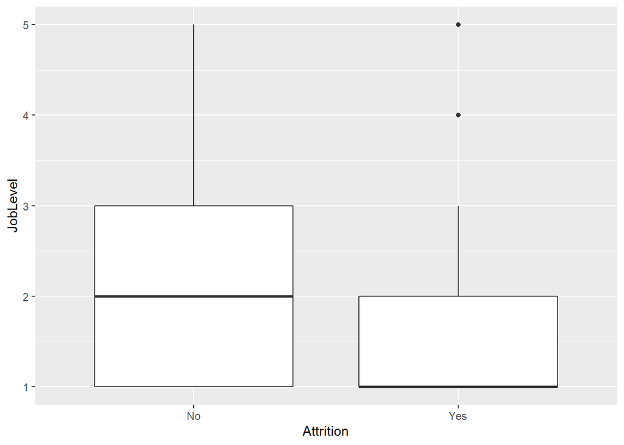

```r
ggplot(work, aes(x=Attrition, y=JobLevel))+geom_boxplot()
```

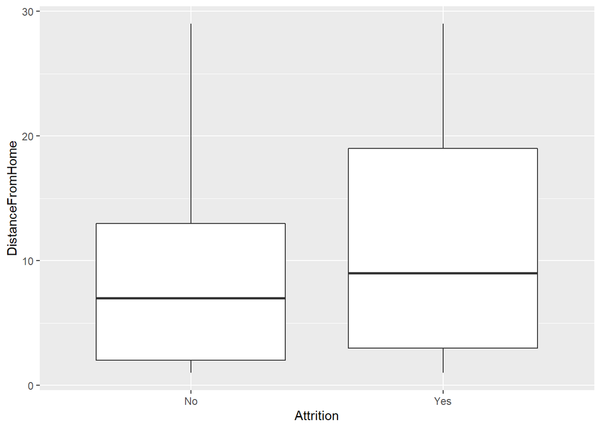

```r
ggplot(work, aes(x=Attrition, y=DistanceFromHome))+geom_boxplot()
```

#Here, we drop the variables that have only one value. Variables with no standard deviation are of no use to us in this analysis.

```r
#Drop variables with no standard deviation
work <- subset(work, select = -c(EmployeeCount, StandardHours, Over18))
Case2PredictionsSeanMcWhirter_Attrition <- subset(Case2PredictionsSeanMcWhirter_Attrition, select = -c(EmployeeCount, StandardHours, Over18))
```

#With the correlation plot below, we are inspecting correlation between numeric variables. As we can see, there are quite a few variables that are correlated with one another.  
#This could pose a problem, so we will attempt to deal with them later on if they become problematic.

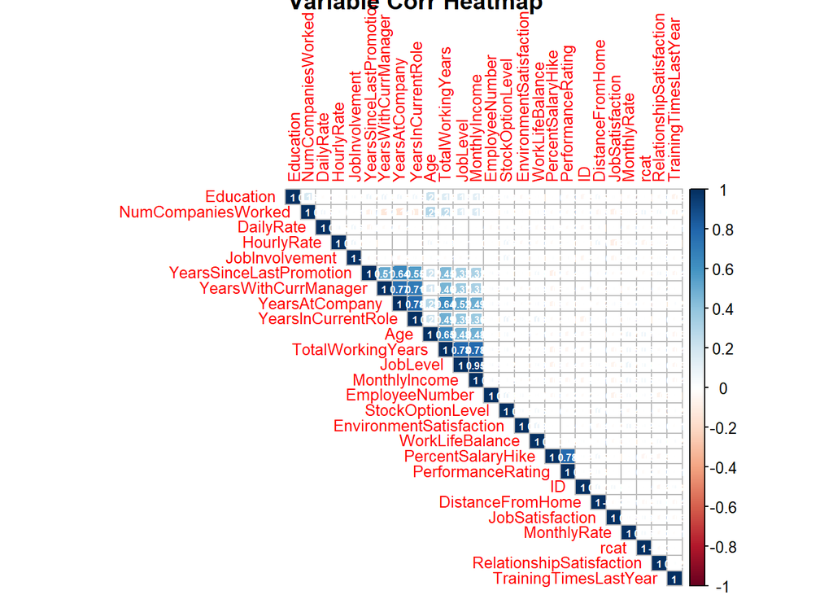

```r
#corrplot

work %>% keep(is.numeric)%>% na.omit %>% cor %>% corrplot("upper", addCoef.col = "white", number.digits = 2,
             number.cex = 0.5, method="square",
             order="hclust", title="Variable Corr Heatmap",
             tl.srt=90, tl.cex = 0.8,)
```

#Feature Engineering attempt. The goal here was to combine differnet variables to try and pull the attrition density away from the non-attrition.  
#Quite a few hours went into this, however no beneficial outcome came of it due to my lack of knowledge in Feature Engineering.

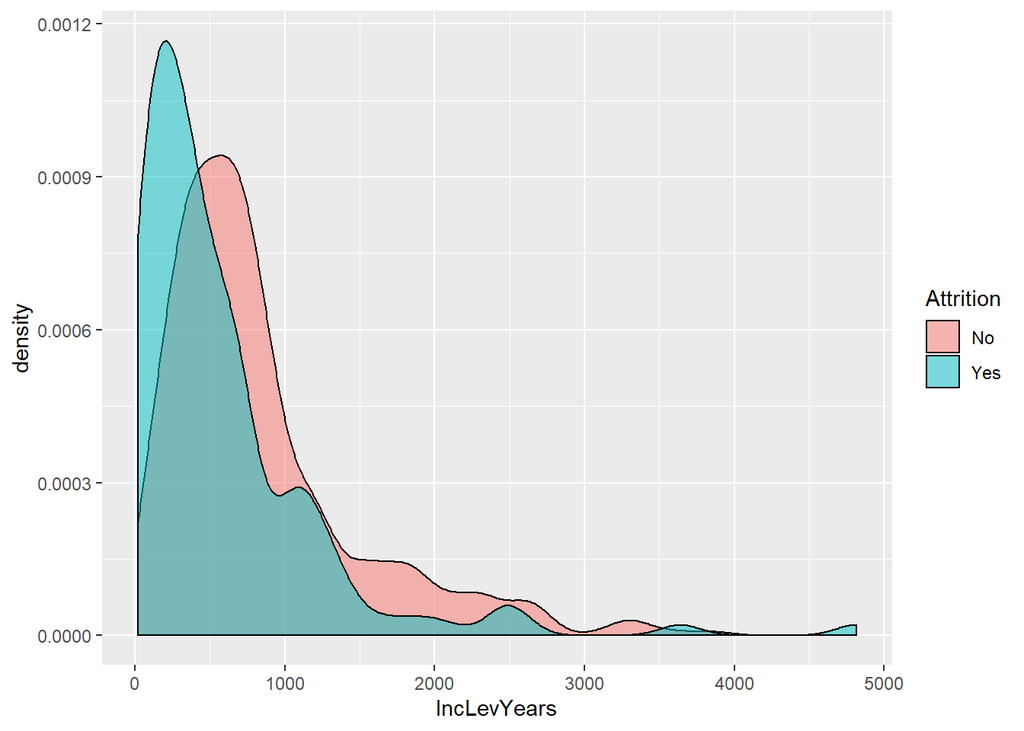

```r
work_test<-work

work_test<-work_test%>%mutate(IncLevYears=((JobLevel+TotalWorkingYears+YearsAtCompany)*Age))
work_test<-work_test%>%mutate(IncLevYears2=(YearsSinceLastPromotion+YearsAtCompany))
work_test<-work_test%>%mutate(IncLevYears3=(JobInvolvement+log(MonthlyIncome)+JobLevel+TotalWorkingYears+YearsAtCompany+YearsInCurrentRole))
work_test<-work_test%>%mutate(IncLevYears4=NumCompaniesWorked+Age+YearsSinceLastPromotion)

#work<-work%>%mutate(CoRolePro=YearsInCurrentRole*YearsAtCompany*YearsSinceLastPromotion)
work_test<-work_test%>%mutate(CoRolePro2=(YearsSinceLastPromotion+YearsWithCurrManager+YearsAtCompany))


#work<-work%>%mutate(test=(((MonthlyIncome*JobInvolvement)/TotalWorkingYears)


numplot <- function(df, explan, resp) {
  ggplot(data = df) + geom_density(aes_string(x = explan, fill = resp), alpha = 0.5)
}

numplot(work_test, explan = "IncLevYears", resp = "Attrition")
```

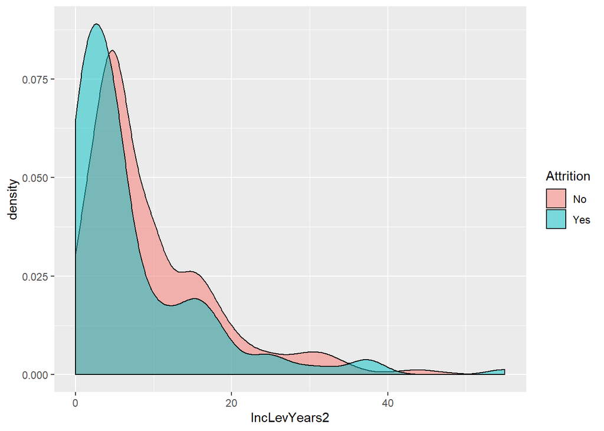

```r
numplot(work_test, explan = "IncLevYears2", resp = "Attrition")
```

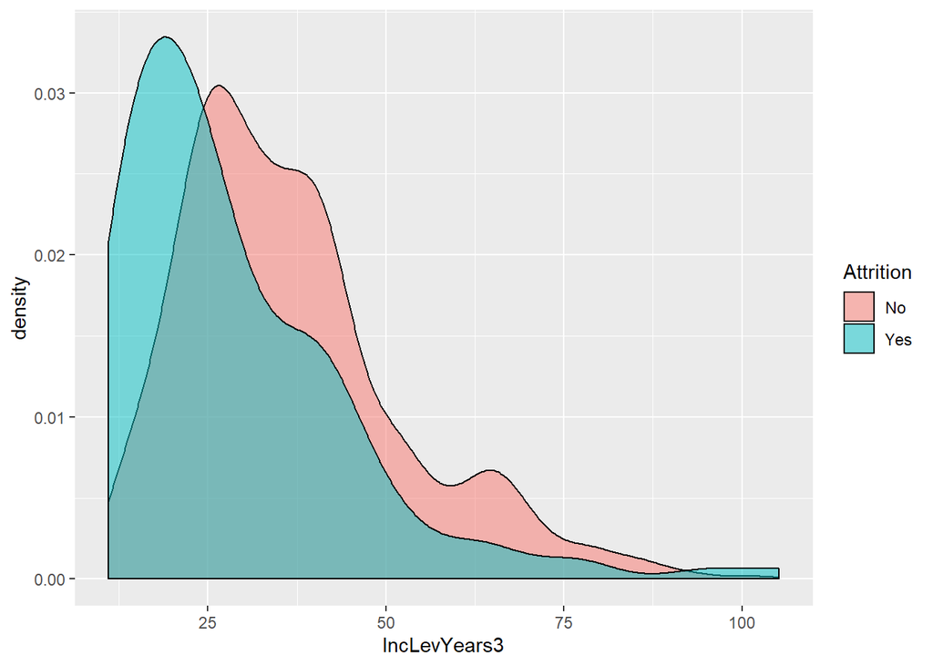

```r
numplot(work_test, explan = "IncLevYears3", resp = "Attrition")
```

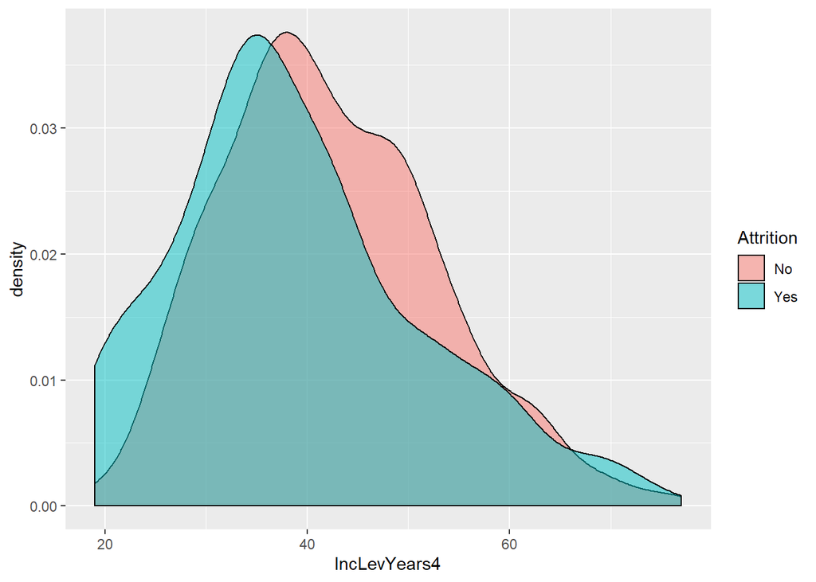

```r
numplot(work_test, explan = "IncLevYears4", resp = "Attrition")
```

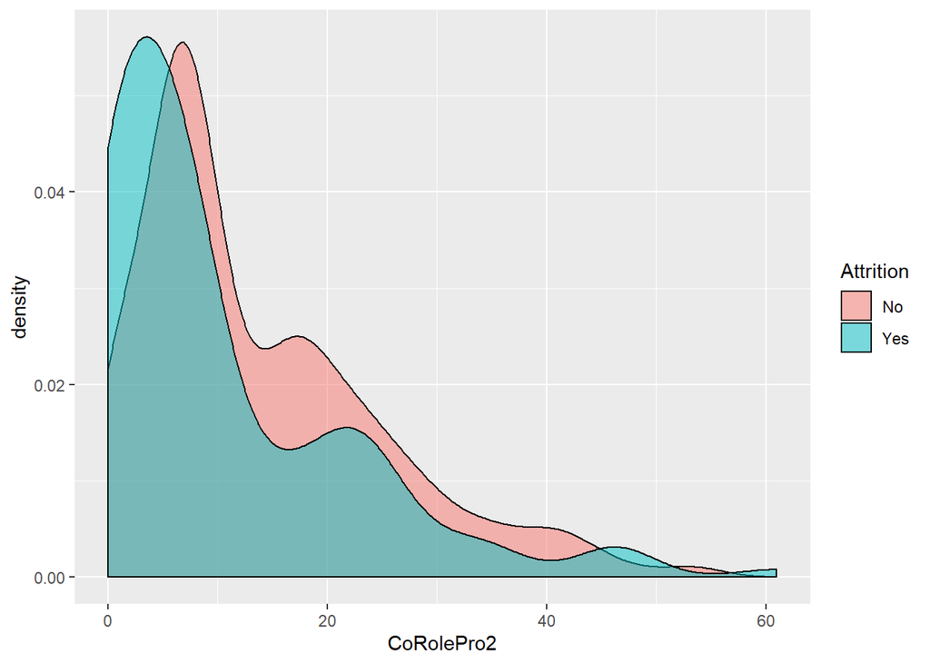

```r
numplot(work_test, explan = "CoRolePro2", resp = "Attrition")
```

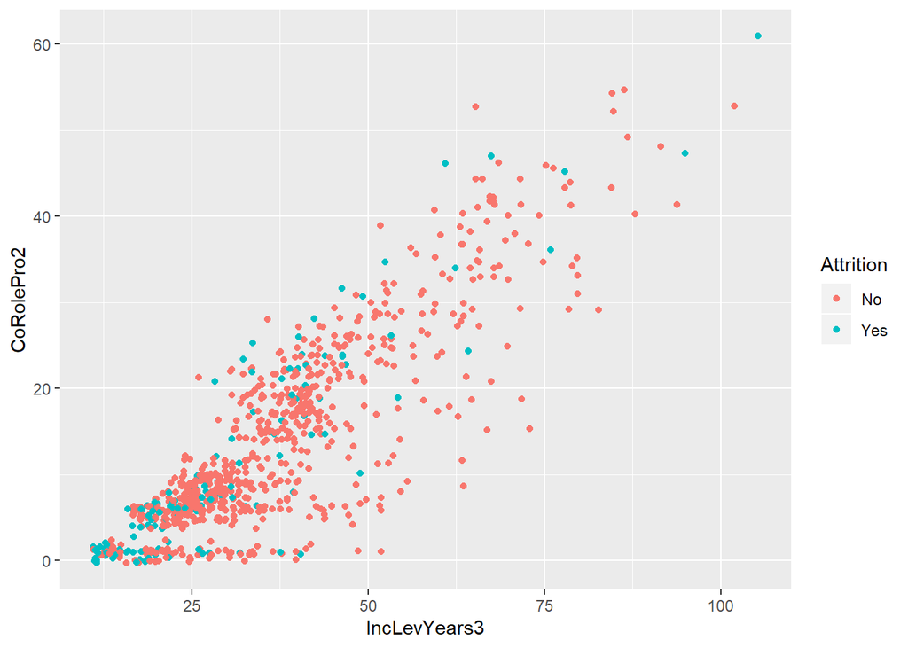

```r
#numplot(work, explan = "test", resp = "Attrition")
work_test%>%ggplot(aes(x=IncLevYears3, y=CoRolePro2, color=Attrition))+geom_point(position="jitter")
```

#Here we are converting the factored variables into integer to be used with Knn

```r
#Converting for the training set
work$JobRole <- as.integer(work$JobRole)
work$OverTime <- as.integer(work$OverTime)
work$BusinessTravel <- as.integer(work$BusinessTravel)
work$Department <- as.integer(work$Department)
work$EducationField <- as.integer(work$EducationField)
work$MaritalStatus <- as.integer(work$MaritalStatus)
work$OverTime <- as.integer(work$OverTime)
work$Gender <- as.integer(work$Gender)

#Converting for the test set
Case2PredictionsSeanMcWhirter_Attrition$JobRole <- as.integer(Case2PredictionsSeanMcWhirter_Attrition$JobRole)
Case2PredictionsSeanMcWhirter_Attrition$OverTime <- as.integer(Case2PredictionsSeanMcWhirter_Attrition$OverTime)
Case2PredictionsSeanMcWhirter_Attrition$BusinessTravel <- as.integer(Case2PredictionsSeanMcWhirter_Attrition$BusinessTravel)
Case2PredictionsSeanMcWhirter_Attrition$Department <- as.integer(Case2PredictionsSeanMcWhirter_Attrition$Department)
Case2PredictionsSeanMcWhirter_Attrition$EducationField <- as.integer(Case2PredictionsSeanMcWhirter_Attrition$EducationField)
Case2PredictionsSeanMcWhirter_Attrition$MaritalStatus <- as.integer(Case2PredictionsSeanMcWhirter_Attrition$MaritalStatus)
Case2PredictionsSeanMcWhirter_Attrition$OverTime <- as.integer(Case2PredictionsSeanMcWhirter_Attrition$OverTime)
Case2PredictionsSeanMcWhirter_Attrition$Gender <- as.integer(Case2PredictionsSeanMcWhirter_Attrition$Gender)
```

#Standardize data for KNN

```r
##Standardize all int columns
work<-work%>%mutate_if(is.numeric,scale)

#For the blank set, we need to keep the ID value as-is so we can use it with our final prediction output.
Case2PredictionsSeanMcWhirter_Attrition<-Case2PredictionsSeanMcWhirter_Attrition%>%mutate_at(vars(-ID),scale)

#Confirm it worked and get final column numbers
#str(work)
#str(Case2PredictionsSeanMcWhirter_Attrition)
```

#KNN Variable Selection–This will run all of the variables and produce the most important ones.

```r
#install.packages("ISLR")
#library(ISLR)
#library(caret)
set.seed(300)
#Spliting data as training and test set. Using createDataPartition() function from caret
indxTrain <- createDataPartition(y = work$Attrition,p = 0.75,list = FALSE)
training <- work[indxTrain,]
testing <- work[-indxTrain,]

#Checking distibution in origanl data and partitioned data
prop.table(table(training$Attrition)) * 100
```

```
##
##       No      Yes
## 83.92037 16.07963
```

```r
prop.table(table(testing$Attrition)) * 100
```

```
##
##       No      Yes
## 83.87097 16.12903
```

```r
prop.table(table(work$Attrition)) * 100
```

```
##
##       No      Yes
## 83.90805 16.09195
```

```r
#Training the model
trctrl <- trainControl(method = "repeatedcv", number = 10, repeats = 3)
set.seed(3333)
knn_fit <- caret::train(Attrition ~., data = training, method = "knn",
 trControl=trctrl,
 preProcess = c("center", "scale"),
 tuneLength = 10)

knn_fit
```

```
## k-Nearest Neighbors
##
## 653 samples
##  33 predictor
##   2 classes: 'No', 'Yes'
##
## Pre-processing: centered (33), scaled (33)
## Resampling: Cross-Validated (10 fold, repeated 3 times)
## Summary of sample sizes: 587, 588, 587, 588, 587, 587, ...
## Resampling results across tuning parameters:
##
##   k   Accuracy   Kappa
##    5  0.8437685  0.13520607
##    7  0.8468852  0.10593626
##    9  0.8489365  0.10048172
##   11  0.8474058  0.08632471
##   13  0.8453698  0.06677583
##   15  0.8428212  0.04244651
##   17  0.8438391  0.04816765
##   19  0.8438549  0.04538871
##   21  0.8428132  0.03486239
##   23  0.8423082  0.03010049
##
## Accuracy was used to select the optimal model using the largest value.
## The final value used for the model was k = 9.
```

```r
knnPredict<-predict(knn_fit, newdata=testing)
confusionMatrix(knnPredict, testing$Attrition)
```

```
## Confusion Matrix and Statistics
##
##           Reference
## Prediction  No Yes
##        No  182  34
##        Yes   0   1
##
##                Accuracy : 0.8433
##                  95% CI : (0.788, 0.889)
##     No Information Rate : 0.8387
##     P-Value [Acc > NIR] : 0.4715
##
##                   Kappa : 0.047
##
##  Mcnemar's Test P-Value : 1.519e-08
##
##             Sensitivity : 1.00000
##             Specificity : 0.02857
##          Pos Pred Value : 0.84259
##          Neg Pred Value : 1.00000
##              Prevalence : 0.83871
##          Detection Rate : 0.83871
##    Detection Prevalence : 0.99539
##       Balanced Accuracy : 0.51429
##
##        'Positive' Class : No
##
```

```r
#knn_fit 2 --> for ROC maximization
ctrl <- trainControl(method = "repeatedcv", repeats = 5, classProbs=TRUE, summaryFunction = twoClassSummary)
kNNFit4 <- caret::train(Attrition ~ .,
                data = work,
                method = "knn",
                tuneLength = 15,
                trControl = ctrl,
                preProc = c("center", "scale"))
kNNFit4
```

```
## k-Nearest Neighbors
##
## 870 samples
##  33 predictor
##   2 classes: 'No', 'Yes'
##
## Pre-processing: centered (33), scaled (33)
## Resampling: Cross-Validated (10 fold, repeated 5 times)
## Summary of sample sizes: 783, 783, 783, 783, 783, 783, ...
## Resampling results across tuning parameters:
##
##   k   ROC        Sens       Spec
##    5  0.6731115  0.9882192  0.11000000
##    7  0.6891389  0.9953425  0.07428571
##    9  0.6941683  0.9980822  0.06571429
##   11  0.6949119  0.9980822  0.05714286
##   13  0.7084149  0.9989041  0.04857143
##   15  0.7122016  0.9997260  0.03714286
##   17  0.7130137  0.9997260  0.04000000
##   19  0.7214384  0.9997260  0.03714286
##   21  0.7311546  0.9997260  0.03714286
##   23  0.7394912  1.0000000  0.03857143
##   25  0.7400978  1.0000000  0.03142857
##   27  0.7428082  1.0000000  0.03285714
##   29  0.7386301  1.0000000  0.02714286
##   31  0.7401566  1.0000000  0.01857143
##   33  0.7460274  1.0000000  0.01285714
##
## ROC was used to select the optimal model using the largest value.
## The final value used for the model was k = 33.
```

```r
#####Ranking of variable importance

library(mlbench)
control <- caret::trainControl(method="repeatedcv", number=10, repeats=3)

#Train Model
model<- caret::train(Attrition ~ . , data=work, method="lvq", preProcess="scale" , trControl=control)


#Importance estimate
importance<-varImp(model, scale=FALSE)
print(importance)
```

```
## ROC curve variable importance
##
##   only 20 most important variables shown (out of 33)
##
##                         Importance
## OverTime                    0.6679
## MonthlyIncome               0.6567
## TotalWorkingYears           0.6563
## YearsAtCompany              0.6470
## StockOptionLevel            0.6455
## MaritalStatus               0.6438
## JobLevel                    0.6406
## YearsInCurrentRole          0.6403
## YearsWithCurrManager        0.6291
## Age                         0.6265
## JobInvolvement              0.6159
## JobSatisfaction             0.5833
## JobRole                     0.5829
## Department                  0.5605
## DistanceFromHome            0.5586
## EnvironmentSatisfaction     0.5532
## WorkLifeBalance             0.5491
## TrainingTimesLastYear       0.5428
## Education                   0.5384
## ID                          0.5371
```

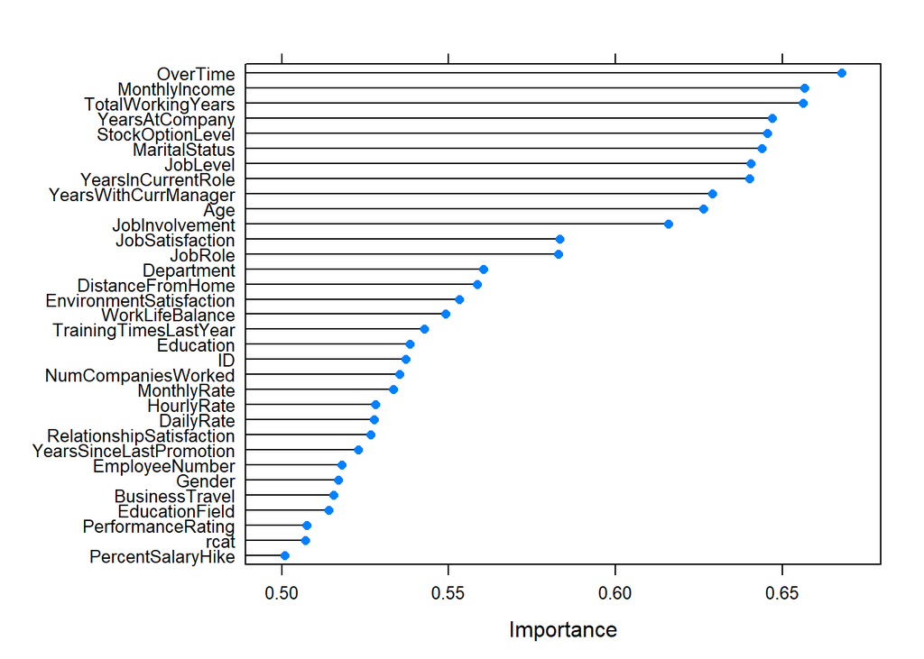

```r
plot(importance)
```

```r
####Ranking of variable importance via Recursive Feature Elimination (RFE)
set.seed(7)
# define the control using a random forest selection function
control <- rfeControl(functions=rfFuncs, method="cv", number=3)
# run the RFE algorithm
results <- rfe(work[,3:32], work[,2], sizes=c(3:32), rfeControl=control)
# summarize the results
#print(results)
# list the chosen features
predictors(results)
```

```
##  [1] "TotalWorkingYears"        "NumCompaniesWorked"
##  [3] "YearsAtCompany"           "MonthlyIncome"
##  [5] "JobLevel"                 "Education"
##  [7] "YearsInCurrentRole"       "YearsSinceLastPromotion"
##  [9] "Attrition"                "MaritalStatus"
## [11] "MonthlyRate"              "HourlyRate"
## [13] "JobRole"                  "WorkLifeBalance"
## [15] "StockOptionLevel"         "BusinessTravel"
## [17] "EducationField"           "DailyRate"
## [19] "Gender"                   "EmployeeNumber"
## [21] "OverTime"                 "PercentSalaryHike"
## [23] "JobInvolvement"           "RelationshipSatisfaction"
```

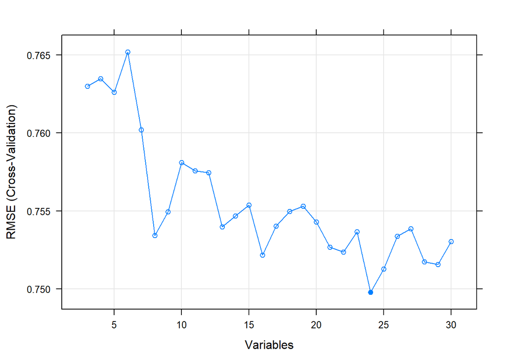

```r
# plot the results
plot(results, type=c("g", "o"))
```

```r
#str(work)
```